# 第7回 多変数関数と可視化

経済学基礎数学II

第7回

多変数関数と可視化

2 変数関数・3 次元グラフ・等高線

経済学基礎数学II

第7回 — Topic01

2 変数関数と等高線

地図はなぜ等高線を使うか

## 第7回の道のり

1

2 変数関数

演習 1-1・1-2

代入と9マスの表

2

等高線の描き方

演習 2-1〜2-3

等高線の式と形

3

経済の等高線

演習 3-1〜3-3

無差別・等生産量

4

3 次元グラフ

演習 4-1・4-2

第7回の総ざらい

いまココ — 変数が $2$ つになる。まず山を地図にする

## 前回の振り返り

前回のポイント — 前半の復習と中間小テスト

Q: ここまで、動かせる数はいくつだったか

- **範囲は前半のすべて**: 前半の道具をひととおり確かめた
- **動かせる数（変数）は $1$ つ**: $x$ を決めると、$y$ が $1$ つ決まる
- **絵は $1$ 本の曲線**: 傾きも、その場所ごとに $1$ つの数

ここから、変数が **$2$ つ** になる

## $1$ 変数の関数の入力と出力

用語 — $1$ 変数の関数

$$y = f(x)$$

- **変数**：$x$ のように、自由に動かせる数
- **入れる数 $x$・出る数 $y$**：$x$ を決めると、$y$ が $1$ つ決まる
- **グラフの読み方**：横に $x$ 縦に $y$ をとる。$y = 2x + 1$ なら点 $(2, 5)$

グラフは、入れた数と出た数の地図。$f(2) = 5$ は、その点 $1$ つ

## このトピックで学ぶこと

- **$z = f(x, y)$**：変数が $2$ つある関数。出力は $y$ ではなく $z$
- **代入するだけ**：値を出すのに、新しい計算は要らない
- **グラフを描く**：格子の表に高さを書くと、山の形が見えてくる
- **等高線**：同じ高さの点をつないだ線

紙は平らで、高さを描く方向がない。そこを工夫する回

## $2$ 変数への入口

動かせる数は、ここまで $1$ つ。ここから $2$ つ

- **何をやるか**：変数が $2$ つある関数を、平らな紙に描けるようにする
- **どこで要るか**：りんごとみかんの数で、満足が決まる
- **いつ必須か**：決めるものが $1$ つで済む経済の話は、めったにない

この回では、まだ微分をしない。目で見えるようにするだけ

## 変数が $2$ つある関数

定義 — $2$ 変数関数

$$z = f(x, y)$$

- **入力（変数）**：$x$ と $y$ 自由に決められる $2$ つの数
- **出力（結果）**：$z$ $x$ と $y$ を決めると $1$ つに決まる数
- **$1$ 変数との違い**：$y = f(x)$ に、入力がもう $1$ 本増えただけ

**出力は $y$ ではなく $z$** $y$ は入力に取られている

## $1$ 変数と $2$ 変数の呼び名のずれ

|  | $1$ 変数 | $2$ 変数 |
| --- | --- | --- |
| 入力 | $x$ | $x$ と $y$ |
| 出力 | $y$ | $z$ |
| 絵 | 平面の上の**曲線** | 空間の中の**曲面**（山の表面） |
| 例 | $f(x) = 2x + 1$ | $h(x, y) = 10 - x^2 - y^2$ |

ここを混同すると、この先ずっと分からなくなる  
次のページで、$h(x, y)$ に数を入れてみる

## $2$ 変数関数の値の求め方

[figure not shown]

$h(x, y)$ は、地点 $(x, y)$ の標高（m）。$1$ つ目が $x$、$2$ つ目が $y$  
$h(2, 1) = 10 - 2^2 - 1^2 = 5$（$x = 2$・$y = 1$ を入れる）

## 演習 1-1 代入で出す値

演習 1-1

計算ドリル7 のブロック $1$「$f(x,y)$ に数を入れて値を出す」。  
動画の答え合わせは 問 $1$

- **復習 A** $f(x) = x^2 + 3$ について、$f(2)$ と $f(-2)$
1. $f(x, y) = x^2 + 3y$ について、$f(2, 1)$ と $f(4, -2)$
2. $f(x, y) = x^2 + 2y$ について、$f(3, 1)$ と $f(-2, -1)$

⏸ PAUSE 動画を止めて、ノートに全部解く。問 $1$ が解けたら再生に戻る  
復習も解く。解説しない問題は、配った答えで確かめる

## 演習 1-1 の答え — 問 $1$

**問 $1$** $f(x, y) = x^2 + 3y$ について、$f(2, 1)$ と $f(4, -2)$

① どこを見る

$1$ つ目が $x$  
$2$ つ目が $y$

② 使う道具

記号の場所に  
数を書き入れる

③ 当てはめる

$2^2 + 3 \times 1$  
$4^2 + 3 \times (-2)$

こたえ

$f(2, 1) = 7$ $f(4, -2) = 10$

順番を取り違えると $f(-2, 4) = 16$ $1$ つ目が $x$ $2$ つ目が $y$

## グラフに要る $3$ 本目の軸

[figure not shown]

入力 $x,\ y$ で床の $2$ 本を使い切る。出力 $z$ は $3$ 本目の軸＝**高さ**

## 点 $(1, 1)$ に立てる高さ $8$ の柱

[figure not shown]

床の点 $(x, y)$ に、高さ $z = h(x, y)$ の柱を立てる。$25$ 本で山の形

## 表で見える山の形

丘の式 $h(x, y) = 10 - x^2 - y^2$  
$x$ を横・$y$ を縦に並べた**格子**にして、マス目に $z = h(x, y)$ を書く

[figure not shown]

真ん中の $10$ がいちばん高い。濃いマスほど高い（**濃さ＝高さ**）

## $3$ 次元で描いた $h$ の山

[figure not shown]

柱の頭をつなぐと**曲面**（山の表面）。これが $h(x, y)$ のグラフ

## ◼ 表を手で埋める $3$ STEP

$h$ の表を、$1$ 度は自分の手で埋める。$25$ マスで山の形が出てくる

1. **横に $x$ 縦に $y$ を並べる**（どちらも $-2$ から $2$ まで）
2. **マスごとに代入して $z$ を書く**（$h(x, y) = 10 - x^2 - y^2$ に入れる）
3. **同じ数のマスを目で追う**（$9$ が $4$ つ、$6$ が $4$ つ）

次は、自分で $9$ マスの表を埋める

## 演習 1-2 $9$ マスの表

演習 1-2

計算ドリル7 のブロック $2$「表を埋める」。  
動画の答え合わせは 問 $1$

- **復習 B** $y = 2x + 1$ について、$x = 0,\ 1,\ 2$ のときの $y$ を表に
1. $f(x, y) = 3x + 2y$ の $9$ マスの表を埋める  
   （横に $x = 0,\ 1,\ 2$・縦に $y = 2,\ 1,\ 0$）
2. $f(x, y) = x^2 + y^2$ の $9$ マスの表と、いちばん小さいマスの $(x, y)$  
   （横に $x = -1,\ 0,\ 1$・縦に $y = 1,\ 0,\ -1$）

⏸ PAUSE 動画を止めて、ノートに全部解く。問 $1$ が解けたら再生に戻る  
復習も解く。解説しない問題は、配った答えで確かめる

## 演習 1-2 の答え — 問 $1$

**問 $1$** $f(x, y) = 3x + 2y$ の表を埋める（横に $x$ 縦に $y$）

① どこを見る

横が $x$ 縦が $y$  
マスは $9$ つ

② 使う道具

$1$ マスずつ  
演習 1-1 と同じ代入

③ 当てはめる

$x = 1,\ y = 2$ なら  
$3 \times 1 + 2 \times 2$

こたえ

$y = 2$：$4,\ 7,\ 10$ $y = 1$：$2,\ 5,\ 8$ $y = 0$：$0,\ 3,\ 6$

右へ $+3$ 上へ $+2$ ずつ増える。この規則が、そのまま検算

## 平らな紙で高さを描く工夫

紙は平らなのに、高さを描けるのか

- **何をやるか**：山の高さを、平らな紙の上で表す
- **なぜ要るか**：立体の絵は、見る向きで裏側が隠れる。手で描くのも大変
- **どうするか**：**同じ高さの点を、線で結ぶ**

紙は平らでも、高さは描ける。この線が**等高線**

## 登山地図の細い線

用語 — 等高線

**この線の上は、どこも同じ標高**、という意味の線  
$z = f(x, y)$ の値が同じ点だけを結んだ線

- **描き方**：標高が同じ点だけを結び、真上から見た形で描く
- **なぜ線か**：紙が平らで、高さを上下に描く方向がない
- **代わりに**：**線に書いた数**が高さ、**間隔**が急さ
- **決まりごと**：$1$ 枚の地図では、線と線の**標高差をそろえて**引く

内側ほど高い丘なら、線が閉じて小さくなる中心が山頂  
内側ほど高いかは、**線に書いた数**で確かめる

## 立体を押しつぶした等高線図

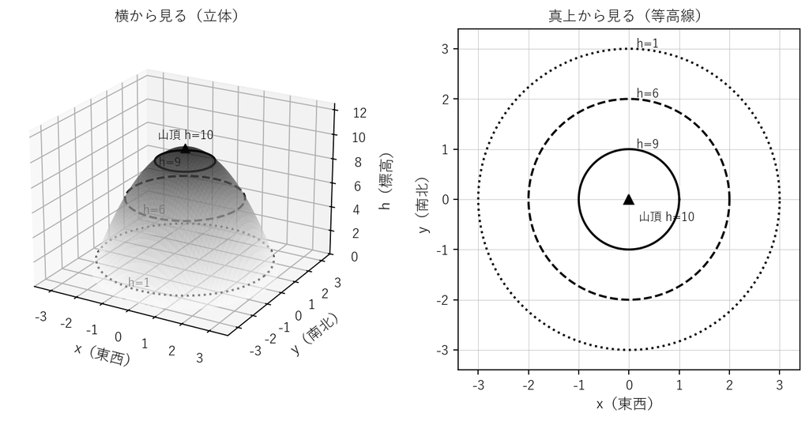

高さ $9,\ 6,\ 1$ で切った輪。半径 $1,\ 2,\ 3$ が出る $3$ つを選んだ

## 同じ数のマスをつないだ円

[figure not shown]

高さ $6$ なら半径 $2$ 高さ $1$ は表の外 $h(3, 0) = 10 - 9 = 1$ で半径 $3$  
この丘では、高さ $10$ 未満の等高線は円 $1$ 本

## 線の間隔と坂の急さ

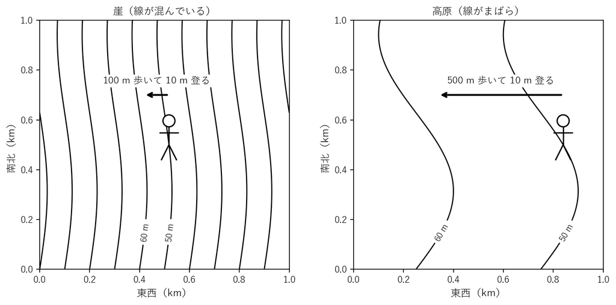

図の「崖」＝**急な坂**。標高差 $10$ m に、急な坂は $100$ m・高原は $500$ m 歩く

## ⚠ よくある $3$ つの取り違え

✕ こうしがち

出力を $y$ と書く

$g(x, y) = 2x + 3y$ で  
$g(-2, 4)$ を $g(4, -2)$ と読む

線の間隔が狭い ＝  
標高差が大きい、と読む

○ 正しくは

出力は $z$ $y$ は入力の名前

$1$ つ目が $x$ $2$ つ目が $y$  
$g(-2, 4) = 8$ $g(4, -2) = 2$

標高差をそろえた地図なら  
狭いのは歩く距離のほう

どれも、記号の**場所**を読み違えたことから起きる

## まとめ

- 変数が $2$ つの関数は $z = f(x, y)$ 出力は $z$
- 値を求めるのは、記号の場所に数を書き入れるだけ
- グラフは、高さの軸を足した立体。柱の頭をつなぐと山の表面
- 格子の表にすると山が見える。マスの濃さが高さ
- 同じ数をつなぐと等高線。この線の上は、どこも同じ標高
- 標高差をそろえた地図なら、線の間隔が狭いところは急

演習のページの残りの問題（**計算ドリル7 のブロック $1$・$2$**）を解く  
→ 次は「等高線の描き方」

経済学基礎数学II

第7回 — Topic02

等高線の描き方

手で描く・覚える形は 3 つ

## 第7回の道のり

1

2 変数関数

演習 1-1・1-2

代入と9マスの表

2

等高線の描き方

演習 2-1〜2-3

等高線の式と形

3

経済の等高線

演習 3-1〜3-3

無差別・等生産量

4

3 次元グラフ

演習 4-1・4-2

第7回の総ざらい

いまココ — コンピュータを見るのは、そのあと

## このトピックで学ぶこと

- **等高線の式**：高さ $c$ を決めて、$f(x, y) = c$ を解く
- **間隔と急さ**：標高差をそろえると、間隔が急さを表す
- **$3$ つの形**：おわん・鞍・平らな板
- **切って見る**：片方を止める（数を入れる）と、$1$ 変数の関数に戻る

高さ $c$ を決めるごとに、等高線が $1$ つに決まる

## 等高線を描く $3$ STEP

ここは必ず自分の手で描く。コンピュータで見るのは、そのあと

1. **$z$ の値を $1$ つ決める**：高さ $c$ を $1$ つ選ぶ
2. **その高さになる点の条件を出す**：直線は $y = \cdots$ に解く。円は半径を読む
3. **線でつなぐ**：条件に合う点を、なめらかに結ぶ

この $3$ STEP は、後半に出る経済の曲線でもそのまま使う

## 等高線の式と高さ $c$

定義 — 等高線の式

$$f(x, y) = c$$

- **$c$**：高さを $1$ つに決めた数。地図に実際にある高さから選ぶ
- **$xy$ 平面**：$x$ と $y$ を描いた平らな面 ＝ 地図
- **$1$ つの $c$ に等高線が $1$ つ**：$c$ を変えれば、別の線になる

前のトピックの丘 $h = 10 - x^2 - y^2$ なら  
$c = 10$ は山頂の $1$ 点だけ。$10$ より上の $c$ には線が無い

## 式から出す標高 $9$ の線

丘の高さは $h(x, y) = 10 - x^2 - y^2$（地点 $(x, y)$ の標高・m）

$10 - x^2 - y^2$

$= 9$

$h$ を $9$ に固定する

$-x^2 - y^2$

$= -1$

$10$ を右へ移す

$x^2 + y^2$

$= 1$

両辺に $-1$ を掛ける

$c = 6$ なら $x^2 + y^2 = 4$ $c = 1$ なら $x^2 + y^2 = 9$

## 手で引く $3$ 本の円

[figure not shown]

半径は $2$ 乗すると右辺になる数。右辺が $4$ なら $2$、$9$ なら $3$  
線は何本でも引ける。形を見るなら、半径がきりのよい $3$ 本で足りる

## 等高線の間隔と斜面の急さ

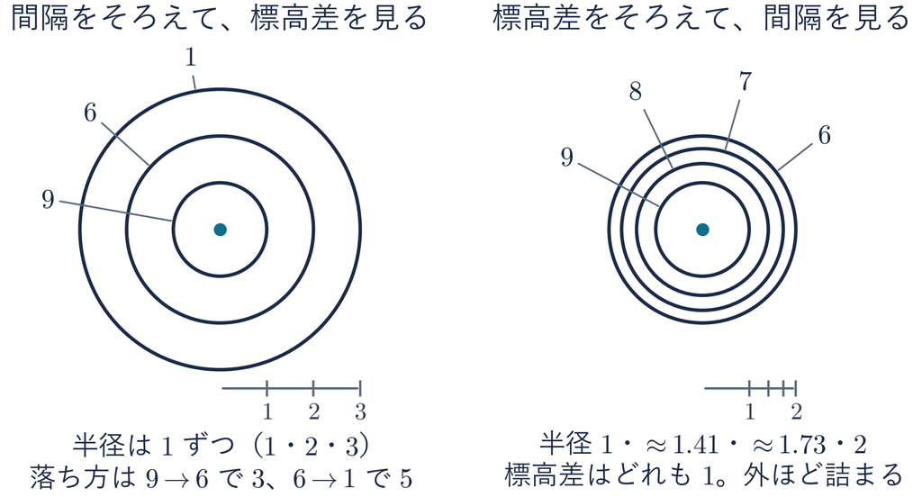

標高差 ＝ となり合う線の高さの差。  
標高 $8$ の線は $x^2 + y^2 = 2$ 半径 $\sqrt{2}$ は約 $1.41$  
間隔だけで比べてよいのは、**標高差がそろっているとき**だけ

## 平らな板の等高線

$z = 2x + y$ の等高線。$z = c$ とおいて $y$ について解くと $y = -2x + c$

| $c$ | 等高線 |
| --- | --- |
| $0$ | $y = -2x$ |
| $2$ | $y = -2x + 2$ |
| $4$ | $y = -2x + 4$ |

[figure not shown]

**切片**：直線が $y$ 軸と交わる所の $y$  
どれも傾き $-2$ 動くのは切片だけ ＝ **平行な直線**

## 覚えておく $3$ つの形

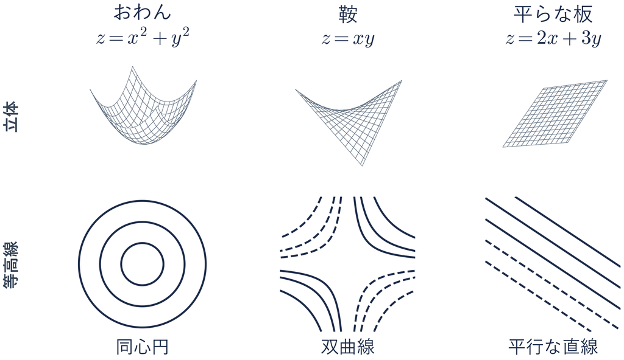

上が立体、下が等高線。まん中の**鞍**は、あとの回で決定的な役をする  
等高線の破線は、$z$ がマイナスの線（鞍と平らな板）

## $3$ つの形の式と等高線

| 名前 | 式の例 | 立体の形 | 等高線 |
| --- | --- | --- | --- |
| **おわん** | $z = x^2 + y^2$ | 底が $1$ つあるくぼみ | 同心円 |
| **鞍（くら）** | $z = xy$ | 峠。馬の鞍の形 | 双曲線（$c \neq 0$） ＝ 反比例 |
| **平らな板** | $z = 2x + 3y$ | 傾いた平面 | 平行な直線 |

**見分け方** $x^2$ と $y^2$ に同じ正の数を掛けた和なら**おわん**  
（$z = -x^2 - y^2$ のように $2$ つともマイナスなら上下逆の**丘**）  
$xy$ の項だけの $z = axy$（$a \neq 0$）なら**鞍** $1$ 乗だけなら**平らな板**

おわんの $2$ つの前の数（係数）が同じ正の数なら、形は同じ  
変わるのは急さだけ（$z = 3x^2 + 3y^2$ もおわん）

## 鞍の形とまん中の峠

用語 — 鞍（くら）

$$z = xy$$

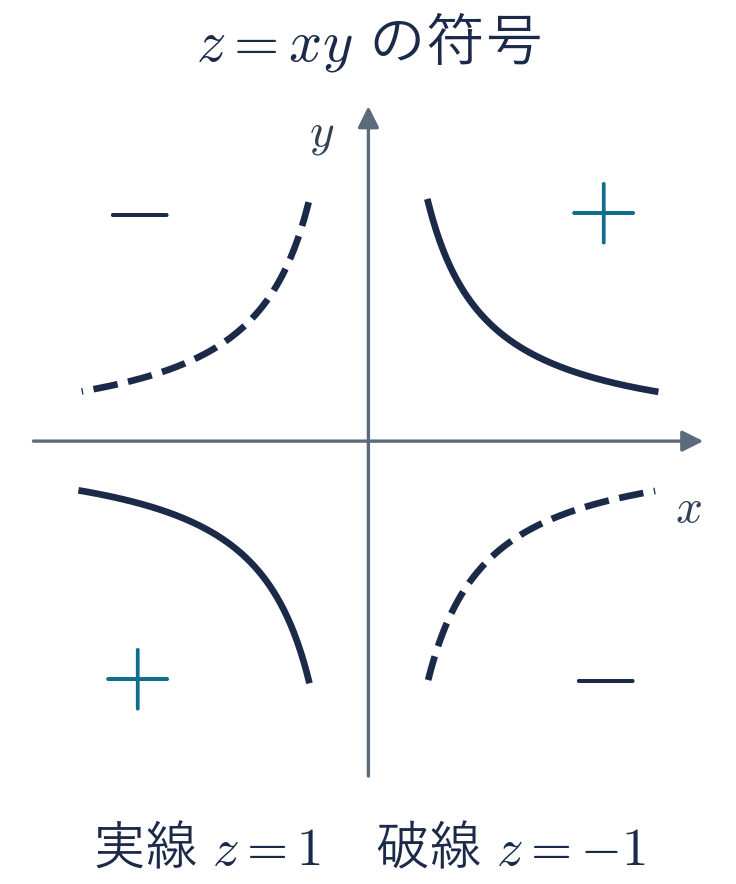

- **形**：峠の形。$y = x$ の上は $z = x^2$（まん中が谷底）  
  $y = -x$ の上は $z = -x^2$（まん中が山頂）
- **符号**：$(1, 1)$ なら $z = 1$ $(1, -1)$ なら $z = -1$  
  右上と左下がプラス、残り $2$ つはマイナス
- **等高線**：$c \neq 0$ なら双曲線。反比例 $y = \frac{c}{x}$ のグラフ  
  $c = 0$ なら $xy = 0$ で、$x$ 軸と $y$ 軸

## デモ：止めて、切ってみる

数の話

おわん $z = x^2 + y^2$、鞍 $z = xy$、平らな板 $z = 2x + 3y$

- **何を見るか**：止めて切った線が $1$ 変数の関数に戻ること
- **図の意味**：橙＝$y = 1$、青緑＝$x = 1$ で止めた切り口
- **操作**：右の柱のタブ $3$ つと「回す」。ドラッグでも回る

ミッション おわん・鞍・平らな板の $y = 1$ の  
切り口から、放物線を探す

※ 次のスライドへ進むときは、デモの枠の外を一度クリックしてから ← → キーを押す

[interactive chart not shown]

## ⚠ よくある $3$ つの取り違え

✕ こうしがち

高さが下がれば  
輪も小さくなる、と思う

$z = 2x + 3y$ の等高線を  
曲がった線で描く

おわんも丘も  
外へ行くほど高い

○ 正しくは

丘では、  
高さが下がると輪は**大きく**  
$c$ が $9 \to 6$ で半径は $1 \to 2$

$1$ 乗だけの式は  
まっすぐな直線

おわんは外ほど高い  
丘は外ほど低い

迷ったら、**式に $1$ 組の数を入れて**たしかめる

## 演習 2-1・2-2・2-3 等高線の式と形

演習 2-1・2-2・2-3

計算ドリル7 ブロック $3$〜$5$ 動画の答え合わせは各ブロックの 問 $1$

**演習 2-1** ブロック $3$  
答える：$y = \cdots$ と傾き。問 $3$ は半径

- **復習 C** $y = -2x + 6$ の傾きと、  
  $y$ 軸と交わる点の $y$
1. $z = x + y$ の、$z = 5$ の等高線
2. $z = 6x + y$ の、$z = 12$ の等高線
3. $z = x^2 + y^2$ の、$z = 49$ の等高線

**演習 2-2** ブロック $4$  
答える：形の名前と等高線の形

- **復習 D** $y = 12/x$ で $x = 3$ の  
  ときの $y$ と、グラフの名前
1. $z = 4x + 7y$
2. $z = 6x^2 + 6y^2$
3. $z = 2xy$

**演習 2-3** ブロック $5$  
答える：止めた式と形

- **復習 E** $y = x^2 + 6$ は、$y = x^2$ を  
  どちらへいくつずらしたか
1. $z = x^2 + y^2$ を $y = 4$ で止める
2. $z = 5x + 2y$ を $y = 3$ で止める

⏸ PAUSE 動画を止めて、ノートに全部解く。問 $1$ が解けたら再生に戻る  
復習も解く。解説しない問題は、配った答えで確かめる

## 演習 2-1 の答え — 問 $1$

**問 $1$** $z = x + y$ の、$z = 5$ の等高線

① どこを見る

$z$ の場所に  
$5$ を入れる

② 使う道具

$x + y = 5$ を  
$y$ について解く

③ 当てはめる

$y = 5 - x$  
並べ替えるだけ

こたえ

$y = -x + 5$（傾き $-1$ の直線）

$c$ を変えても傾きは $-1$ のまま。動くのは切片だけ

## 演習 2-2 の答え — 問 $1$

**問 $1$** $z = 4x + 7y$ は、$3$ つの形のどれか

① どこを見る

$x$ も $y$ も  
$1$ 乗だけ

② 使う道具

$3$ つの形の表と  
見くらべる

③ 当てはめる

$2$ 乗も $xy$ も  
入っていない

こたえ

**平らな板**。等高線は平行な直線

表の見分け方のとおり。$1$ 乗だけなら板  
前の数（$4$ や $7$）を変えても板のまま。変わるのは坂の向きと急さ

## 演習 2-3 の答え — 問 $1$

**問 $1$** $z = x^2 + y^2$ を、$y = 4$ に止めたとき

① どこを見る

止めるのは $y$  
動くのは $x$

② 使う道具

$y$ の場所に  
$4$ を書き入れる

③ 当てはめる

$z = x^2 + 4^2$  
$4^2 = 16$

こたえ

$z = x^2 + 16$（$z = x^2$ を上に $16$ ずらした放物線）

止めた瞬間、変数は $1$ つ。見慣れた放物線に戻る  
$1$ 乗だけの式は、止めても直線になる

## まとめ

- 等高線の式は $f(x, y) = c$ $c$ を決めると、等高線が $1$ つに決まる
- $x^2 + y^2 = 1$ が円なのは、原点からの距離が $1$ だから
- 標高差をそろえると、線の間隔が急さを表す
- 覚える形は $3$ つ。おわん・鞍・平らな板
- 片方を止めて切ると、$1$ 変数の関数に戻る。  
  この切り口の傾きを出すのが、あとの回の入口

演習のページの残りの問題（**計算ドリル7 のブロック $3$・$4$・$5$**）を解く  
→ 次は「経済に出てくる等高線」

経済学基礎数学II

第7回 — Topic03

経済に出てくる等高線

無差別曲線と等生産量曲線

## 第7回の道のり

1

2 変数関数

演習 1-1・1-2

代入と9マスの表

2

等高線の描き方

演習 2-1〜2-3

等高線の式と形

3

経済の等高線

演習 3-1〜3-3

無差別・等生産量

4

3 次元グラフ

演習 4-1・4-2

第7回の総ざらい

いまココ — 山の地図が、そのまま経済の図になる

## このトピックで学ぶこと

- **効用（こうよう）関数**：うれしさ＝満足の度合いを表す関数 $u(x, y)$
- **無差別曲線**：無差別 ＝ **どちらでもよい**。  
  満足が同じ組み合わせを結んだ線
- **等生産量曲線**：作れる量が同じ組み合わせを結んだ線
- **見る範囲**：量はマイナスにならない。  
  この回はさらに $x > 0$ $y > 0$ に絞る

どちらの曲線も、正体は等高線

## 経済に移す山の道具

道具は変わらない。高さが同じ点を結ぶ等高線 $f(x, y) = c$ のまま

- **何をやるか**：標高を「満足」や「作れる量」に置きかえる
- **いつ必須か**：持っているお金が決まっているとき、  
  どの組み合わせを選ぶか

名前が $2$ つ増えるだけ。**中身はどちらも等高線**

## 満足の度合いを表す関数

定義 — 効用関数

$u(x, y)$：$2$ つの品物の量から決まる**満足の度合い**

- **$x,\ y$**：りんごの個数・みかんの個数。どちらも $0$ より大きい
- **この回の例**：$u(x, y) = xy$ 掛けた数が、その組み合わせの満足
- **$u$**：満足の大きさを表す数。単位は付けない

数が大きいほど嬉しい。$u = 12$ は $u = 6$ より嬉しい

## 満足が $6$ になる組み合わせ

$u(x, y) = xy$ で、$u = 6$ になる組み合わせ  
（$x$ も $y$ も整数になる組だけ並べた）

| $x$（りんご） | $1$ | $2$ | $3$ | $6$ |
| --- | --- | --- | --- | --- |
| $y$（みかん） | $6$ | $3$ | $2$ | $1$ |

どれも $u = 6$ 本人には、どれを選んでも同じくらい嬉しい

## 満足が同じ組み合わせを結ぶ線

定義 — 無差別曲線

$$u(x, y) = c$$

- **無差別**：どれを選んでも同じくらい嬉しい ＝ どちらでもよい
- **$c$**：満足の大きさ。山では高さだったもの
- **$u = 6$ なら**：$xy = 6$ つまり $y = \frac{6}{x}$（中学の反比例）
- **$1$ 次式なら**：$u = x + 2y$ のような式では  
  線はまっすぐになる

やっていることは $f(x, y) = c$ と同じ。呼び名が変わっただけ

## 無差別曲線を描く $3$ STEP

$u = 6$ の $1$ 本だけを、次の $3$ STEP で引く

1. **$u$ の値を $1$ つ決める**：ここでは $u = 6$
2. **その満足になる点の条件を出す**：$xy = 6$ を $y$ について解くと $y = \frac{6}{x}$
3. **線でつなぐ**：条件に合う点を、直線でつながず、なめらかに結ぶ

量は細かく分けられると考える。$(2.5,\ 2.4)$ も $2.5 \times 2.4 = 6$  
$4$ 点だけの線ではない。$xy = 6$ になる組を**すべて**集めた線

## 右上ほど高い満足

[figure not shown]

$xy = 3,\ 6,\ 12$ の $3$ 本。$(2, 3)$ と $(3, 2)$ は同じ満足

## 同じ式から出る違う絵

[figure not shown]

りんごを $-2$ 個は食べられない。  
この回はさらに $x > 0$ かつ $y > 0$ だけを見る

## ◼ $x$ の範囲を付ける $3$ STEP

例 $u = 2x + y$ の、満足が $6$ の無差別曲線（$y > 0$ の部分だけ）

1. **$y$ について解く**：$2x + y = 6$ の $2x$ を右へ → $y = -2x + 6$
2. **$y > 0$ を不等式にして解く**：$-2x + 6 > 0$ → $6 > 2x$ → $2x < 6$ → $x < 3$
3. **$x > 0$ と合わせる**：$0 < x < 3$

答えは $y = -2x + 6$（$0 < x < 3$）の形で書く  
反比例 $y = \frac{6}{x}$ は $x > 0$ なら $y > 0$。範囲は $x > 0$ だけ

## 演習 3-1・3-2 無差別曲線

演習 3-1・3-2

ブロック $6$「経済のことばで」の 問 $1$・$2$・$4$

1. $u = x + 2y$（パン $x$ 個・牛乳 $y$ 本）  
   $9$ マスの表を埋め、$u = 5$ の組を $2$ つ  
   （横に $x = 1,\ 2,\ 3$・縦に $y = 3,\ 2,\ 1$）
2. $u = 3x + y$（りんご $x$ 個・みかん $y$ 個）  
   （1）$u(3, 2)$  
   （2）満足が $12$ の無差別曲線  
   （$y = \cdots$・$x$ の範囲も）  
   （3）どんな形か
4. $u = xy$（りんご $x$ 個・みかん $y$ 個）  
   （1）$u(2, 5)$  
   （2）満足が $10$ の無差別曲線  
   （$y = \cdots$・$x$ の範囲も）  
   （3）りんごを $5$ 個にすると、  
   みかんは何個で同じ満足か

$1$ と $2$ は $1$ 次式なので線はまっすぐ

⏸ PAUSE 動画を止めて、ノートに全部解く。問 $1$ と 問 $2$ が解けたら再生に戻る  
動画で解説しない問題は、配った答えで確かめる

## 演習 3-1 の答え — 問 $1$

**問 $1$** $u = x + 2y$（パン $x$ 個・牛乳 $y$ 本）の表を埋める

① どこを見る

横に $x$ の値  
縦に $y$ の値

② 使う道具

$x + 2y$ に  
数を入れる

③ 当てはめる

$y = 3$：$7,\ 8,\ 9$  
$y = 2$：$5,\ 6,\ 7$  
$y = 1$：$3,\ 4,\ 5$

こたえ

$u = 5$ は $(x, y) = (1, 2)$ と $(3, 1)$

同じ数のマスをつなぐ。$1$ 次式なので、これは**まっすぐな**無差別曲線

## 演習 3-2 の答え — 問 $2$

**問 $2$** $u = 3x + y$ の $u(3, 2)$ と、$u = 12$ の無差別曲線

① どこを見る

（1）$u(3, 2)$  
（2）$3x + y = 12$

② 使う道具

（1）$x$ に $3$、$y$ に $2$  
（2）$y$ について解く

③ 当てはめる

（1）$3 \times 3 + 2 = 11$  
（2）$y = -3x + 12$

こたえ

$u(3, 2) = 11$ $y = -3x + 12$ の**直線**（$0 < x < 4$）

直線まるごとではない。$-3x + 12 > 0$ → $12 > 3x$ → $3x < 12$ → $x < 4$

## 工場の作れる量

満足のかわりに、工場で**作れる量**を測る

- **何をやるか**：機械と人の数で、作れる量が $1$ つ決まる
- **どこで要るか**：工場が、機械と人の組を決めるとき
- **いつ必須か**：同じ量を作れる組が、いくつもあるとき

満足が作れる量に変わるだけ。**中身は同じ等高線**

## 作れる量を表す関数

定義 — 生産関数

機械と働き手の量から、**作れる量** $Y$（個）を決める関数

- **$K,\ L$**：機械の台数・働き手の人数。どちらも $0$ より大きい
- **文字のわけ**：$K$ は資本（機械）、$L$ は労働（働き手）の頭文字
- **今回の例**：$Y = \sqrt{KL}$ $K = 4,\ L = 9$ なら $\sqrt{36} = 6$ 個

満足の $u(x, y)$ と同じ形。入れる数が $2$ つ、出る数が $1$ つ

## 平方根と $2$ 乗

- **土台**：$3^2 = 9$ なので $\sqrt{9} = 3$（$2$ 乗して $9$ になる正の数）
- **外れる**：$\sqrt{\ }$ の付いた数を $2$ 乗すると、  
  中身に戻る。$(\sqrt{9})^2 = 9$
- **広げる**：$\sqrt{KL} = 6$ の両辺を $2$ 乗すると $KL = 36$

$36$ は生産量ではない。$K$ と $L$ を**掛けた値**

## 作れる量が同じ組み合わせを結ぶ線

定義 — 等生産量曲線

$$Y = c$$

- **$c$**：作れる量。山では高さだったもの
- **つまり**：$\sqrt{KL} = c$ になる $(K, L)$ を結んだ線
- **$Y = 6$ なら**：$KL = 36$

やっていることは $f(x, y) = c$ と同じ。呼び名が変わっただけ

## $6$ 個作れる組み合わせ

$\sqrt{KL} = 6$ の両辺を $2$ 乗すると $KL = 36$

| $K$（機械） | $4$ | $6$ | $9$ | $36$ |
| --- | --- | --- | --- | --- |
| $L$（人） | $9$ | $6$ | $4$ | $1$ |

どれも $6$ 個作れる。機械を減らしたら、**掛けて $36$** になるまで人を増やす

## 生産の等高線

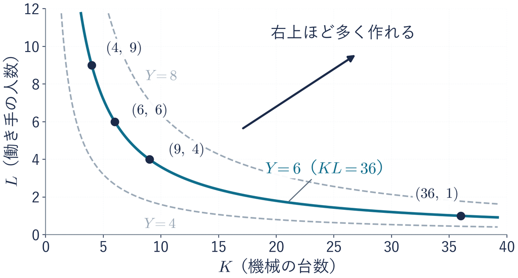

目盛りは違うが、**形は無差別曲線と同じ**  
（右下がりで、原点に向かってふくらむ）

## 演習 3-3 等生産量曲線

演習 3-3

ブロック $6$ の問 $3$ と復習 F。動画の答え合わせは 問 $3$

- **復習 F** $\sqrt{36}$ と $(\sqrt{9})^2$
3. $Y = \sqrt{KL}$（機械 $K$ 台・働き手 $L$ 人）で $6$ 個作る。  
   $K = 2,\ 3,\ 12$ のとき、$L$ は何人か

⏸ PAUSE 動画を止めて、ノートに全部解く。  
問 $3$ が解けたら再生に戻る  
復習も解く。解説しない問題は、配った答えで確かめる

## 演習 3-3 の答え — 問 $3$

**問 $3$** $Y = \sqrt{KL}$ で $6$ 個作る。$K = 2,\ 3,\ 12$ のときの $L$

① どこを見る

$\sqrt{KL} = 6$  
を式にする

② 使う道具

両辺を $2$ 乗して  
$KL = 36$

③ 当てはめる

$L = 36 \div K$  
$36 \div 2 = 18$

こたえ

$L = 18,\ 12,\ 3$（$K = 2,\ 3,\ 12$ の順）

検算：$\sqrt{2 \times 18} = \sqrt{36} = 6$

問 $4$ は演習 3-1・3-2、復習 F は演習 3-3 のページにある

## 曲線に接する直線と傾き

用語 — 接線

曲線に**接する直線**。接する点で、  
曲線と同じ傾きになる

[figure not shown]

前に出てきた、$1$ 変数のグラフの接線と同じもの

## ふくらみと交換してよい比率

[figure not shown]

傾きのマイナスは**減る**向き。マイナスを取った数（$6$ や $1/6$）が  
みかんを減らせる**およその**割合。曲線と重なるのは接する点のそばだけ

## ⚠ よくある $3$ つの取り違え

✕ こうしがち

交わっても平気に見えて  
無差別曲線を交わらせる

線が原点を囲む輪に見えて  
右上ほど満足が低いと思う

$y = f(x)$ のクセで  
縦軸を $Y$ にする

○ 正しくは

$1$ 組の満足は $1$ つ  
線は交わらない

$x$ も $y$ も増えれば  
$xy$ は増える（右上ほど高い）

縦軸は $L$ $Y$ は  
線の脇に書く値

迷ったら、**組み合わせを $1$ つ入れて**満足や生産量を出す

## まとめ

- 満足の度合いを表す関数が、効用関数 $u(x, y)$
- 満足が同じ組み合わせを結んだ線が、無差別曲線
- 生産量が同じ組み合わせを結んだ線が、等生産量曲線
- 同じ式でも、見る範囲が違えば見える形が違う
- ふくらみは、交換してよい比率が場所で変わること

演習のページの残りの問題（**計算ドリル7 のブロック $6$「経済のことばで」**）を解く  
→ 次は「3 次元グラフと等高線図」

経済学基礎数学II

第7回 — Topic04

3 次元グラフと等高線図

回して、切って、見比べる

## 第7回の道のり

1

2 変数関数

演習 1-1・1-2

代入と9マスの表

2

等高線の描き方

演習 2-1〜2-3

等高線の式と形

3

経済の等高線

演習 3-1〜3-3

無差別・等生産量

4

3 次元グラフ

演習 4-1・4-2

第7回の総ざらい

いまココ — 手で描いたあとで、画面で動かして見る

## このトピックで学ぶこと

- **見比べる**：手で描いた $3$ 本の円と、機械が描いた絵が重なること
- **係数を動かす**：$x^2,\ y^2,\ xy$ に掛ける数で、輪が鞍に変わる
- **回して、切る**：鞍は向きしだいで、山にも谷にも見える
- **順序**：手で描いてから、画面で見る。逆にしない

デモをさわるあいだは、式を解かなくてよい。動かして、  
形の変わり方を見るのが目的

## 画面で動かす立体と等高線

手で描けるようになった。同じ絵を、画面の上で動かして見る

- **何をやるか**：係数を動かして、等高線が描き変わるところを見る
- **どこで要るか**：$x^2$ と $xy$ が混ざると描きにくい  
  （例 $z = x^2 + 3xy - y^2$）
- **いつ必須か**：式を少しずつ変えて形の変わり方を追うとき、  
  手描きでは追いつかない

ただし**手で描いてから**。逆にすると、等高線が何なのか分からないまま進む

## 手で描いた $3$ 本の円と画面の円

[figure not shown]

式は $z = 10 - x^2 - y^2$ 左が立体、右が真上から見た地図  
外から 高さ $1,\ 6,\ 9$（半径 $3,\ 2,\ 1$）

## デモ：係数で等高線が変わる

数の話

$z = a x^2 + b y^2 + c xy$。  
$a$・$b$・$c$ は $x^2$・$y^2$・$xy$ に掛ける数（高さではない）

- **何を見るか**：係数をどう変えると輪がつぶれ、双曲線に変わるか
- **図の意味**：橙＝正の高さ、青緑＝負の高さ。数はその線の高さ
- **操作**：右の柱のタブ $4$ つとスライダ $3$ 本で動かす

ミッション 双曲線（鞍）になる $a,\ b,\ c$ を自分で探す

※ 次のスライドへ進むときは、デモの枠の外を一度クリックしてから ← → キーを押す

[interactive chart not shown]

## 係数と形の関係

$z = a x^2 + b y^2 + c xy$ の $a,\ b,\ c$ を動かすと、覚えた形を行き来する  
この $c$ は高さではない。$xy$ に掛ける数

| $a$ と $b$ | $c$ | 画面に出る形 | 等高線 （高さ $0$ 以外） |
| --- | --- | --- | --- |
| 同じ符号 | $0$ | おわん（$a > 0$） 丘（$a < 0$） | 円か楕円の輪 |
| 逆の符号 | $0$ | 鞍 | 双曲線 |
| 同じ符号 | $0$ から大きく | 輪が傾き、 境目をこえて鞍 | 輪 → 直線 → 双曲線 |

高さ $0$ では、おわん・丘は点、鞍は交わる $2$ 本の直線、境目は直線 $1$ 本  
おわんのマイナスの高さ（丘のプラスの高さ）には、線が出ない

## デモ：鞍を回して見る

数の話

おわん $z = x^2 + y^2$、鞍 $z = xy$、平らな板 $z = 2x + 3y$

- **何を見るか**：止めて切った線が $1$ 変数の関数に戻ること
- **図の意味**：橙＝$y = 1$、青緑＝$x = 1$ で止めた切り口
- **操作**：右の柱のタブ $3$ つと「回す」。ドラッグでも回る

ミッション 鞍を回して、谷にも山にも見える向きを探す

※ 次のスライドへ進むときは、デモの枠の外を一度クリックしてから ← → キーを押す

[interactive chart not shown]

## 谷底にも山頂にもなるまん中

鞍 $z = xy$ を真上から見た図。道の式を $y$ に入れて高さを出す

[figure not shown]

**だから**：同じ $1$ 点が、歩く向きで谷底にも山頂にもなる

まん中が山か谷かは、**歩く向き**しだい

## ⚠ よくある $3$ つの取り違え

✕ こうしがち

左の立体と右の地図を  
別々の $2$ つの絵だと思う

線に書いてある数を  
線の番号だと思う

鞍のまん中を  
ただの平らな場所だと思う

○ 正しくは

同じ山を、ななめから見たのが左  
真上から見たのが右

その線の**高さ**。$f(x, y) = c$ の $c$  
（デモで動かした係数とは別）

平らに見える向きもあるが  
右上の道は上り、左上の道は下り

どれも、配ったスライドの $2$ つのデモで確かめられる

## 演習 4-1・4-2 第7回の総ざらい

演習 4-1・4-2

計算ドリル7 のブロック $7$「見分けて解く」（全問）。  
動画の答え合わせは 問 $1$・問 $2$

1. $f(x, y) = 3x^2 - y$ について、$f(2, 5)$
2. $z = 5x + y$ の、$z = 10$ の等高線（$y = \cdots$ の形に）と、その傾き
3. $z = x^2 + y^2$ を $x = 5$ で止めたときの断面の式（$y$ の式）と、その形
4. $z = 4xy$ について（1）$3$ つの形のどれか。等高線はどんな形か  
   （2）$z = 20$ の等高線を $y = \cdots$ の形で書く

⏸ PAUSE 動画を止めて、ノートに全部解く。問 $1$ と 問 $2$ が解けたら再生に戻る  
動画で解説しない問題は、配った答えで確かめる

## 演習 4-1 の答え — 問 $1$

**問 $1$** $f(x, y) = 3x^2 - y$ の $f(2, 5)$

① どこを見る

$x$ に $2$  
$y$ に $5$ を入れる

② 使う道具

$3x^2 - y$ に  
そのまま入れる

③ 当てはめる

$3 \times 2^2 - 5$  
$= 12 - 5$

こたえ

$f(2, 5) = 7$

$3x^2$ は $(3x)^2$ ではない。$2$ 乗してから $3$ 倍。$(3 \times 2)^2 - 5$ なら $31$

## 演習 4-2 の答え — 問 $2$

**問 $2$** $z = 5x + y$ の、$z = 10$ の等高線

① どこを見る

$z$ に $10$ を  
入れて式にする

② 使う道具

両辺から $5x$ を  
引いて $y$ を残す

③ 当てはめる

$5x + y = 10$  
$y = -5x + 10$

こたえ

$y = -5x + 10$（傾き $-5$）

元の立体 $z = 5x + y$ は平らな板。その等高線 $y = -5x + 10$ は直線  
$z$ の値（ここでは $10$）を変えても傾きは $-5$ 切片（足している $10$）だけ動く

## 第7回のまとめ

- 変数が $2$ つの関数は $z = f(x, y)$ 出てくるのは $z$
- 等高線は $f(x, y) = c$ 標高差をそろえれば、間隔が狭いほど急
- 覚える形は $3$ つ（おわん・鞍・平らな板）。  
  無差別曲線も等生産量曲線も等高線
- 片方を止めて切ると、$1$ 変数の関数に戻る。  
  ここが、あとの回への入口
- 係数を $1$ つ動かせば形が変わる。**画面なら見比べも一瞬**

演習のページの残りの問題を解く  
（**計算ドリル7 のブロック $7$「見分けて解く」**）→ 第7回はここまで